# Анализ предсказаний в cloze-task у людей и GPT4o-mini

Андрей Пихтин

2026-06-22

# Введение

## Исследовательский вопрос

В этом исследовании я хочу узнать, повторяются ли паттерны предсказывания слов в задании cloze-task у людей и LLM. LLM в исследовании: GPT4o-mini, выбрана она, потому что это последняя open-source модель от openai на момент проведения исследоавния, к тому же она популяряна среди пользователей.

Именно сравниваются распределения вероятностей частей речи для каждого контекста.

## Гипотеза

ЛЛМ вопроизводит поведение людей на уровне предсказания частей речи

# Данные

В исследовании используются предобработанные при помощи Python данные экспериментов, которые проводились мной в работе исследовательской группы, куда еще входили Вера Монина (бакалавриат ФиКЛ), Наталья Анатольевна Слюсарь, Сериков Олег Алексеевич, Выренкова Анастасия Сергеевна.

Контесты в тесте: данные подобранные для Russian Sentence Corpus (144 предложения всего, 142 в этом исследовании)

Строка - контекст. Колонки - вероятности для каждой части речи, расчитанные из ответов моделей и GPT.

Данные для людей были получены в результате работы центра языка и мозга, нам их передала Алексеева Светлана Владимировна.

Данные для GPT были сгенерированы мной через кастомный алгоритм семплирования, напоминающий beam_search. Для каждого контекста были взяти топ-15 ответов модели, в самих данных хранится намного больше продолжений модели.

Разметка частей речи в обоих датасетах производилась при помощи библиотеки Stanza.

# Setup

```r
library(tidyverse)
library(philentropy)
library(lsa)
library(ggplot2)
library(corrplot)
library(knitr)

theme_set(theme_minimal())
```

# Загрузка данных

Example:

| context | NOUN | VERB | ADJ |
| --- | --- | --- | --- |
| Я всегда с собой беру видео | 0.80 | 0.20 | 0.00 |

```r
human <- read.csv("/Users/andrejpihtin/учеба/комп_мага/R/project/preprocessed_data/human_pos_probs.csv")
gpt <- read.csv("/Users/andrejpihtin/учеба/комп_мага/R/project/preprocessed_data/gpt_pos_probs.csv")
```

## Посмотрим на данные

```r
dim(human)
```

```
## [1] 142  13
```

```r
dim(gpt)
```

```
## [1] 142  14
```

```r
head(human)
```

```
##                                          context        ADJ  ADP       ADV
## 1                             А промывать манную 0.33333333 0.00 0.0000000
## 2 Автор принадлежит к числу последних свидетелей 0.19354839 0.00 0.0000000
## 3                       В багажнике были лопата, 0.04545455 0.00 0.0000000
## 4                                     В бассейне 0.10714286 0.00 0.0000000
## 5                     В вопросе послышался упрёк 0.12500000 0.25 0.1250000
## 6                         В деревнях по-прежнему 0.00000000 0.00 0.1538462
##        CCONJ        DET INTJ      NOUN NUM       PART       PRON SCONJ
## 1 0.00000000 0.00000000    0 0.6666667   0 0.00000000 0.00000000     0
## 2 0.00000000 0.06451613    0 0.5483871   0 0.00000000 0.09677419     0
## 3 0.04545455 0.00000000    0 0.9090909   0 0.00000000 0.00000000     0
## 4 0.00000000 0.00000000    0 0.8928571   0 0.00000000 0.00000000     0
## 5 0.25000000 0.00000000    0 0.0000000   0 0.00000000 0.12500000     0
## 6 0.00000000 0.00000000    0 0.0000000   0 0.07692308 0.00000000     0
##         VERB
## 1 0.00000000
## 2 0.09677419
## 3 0.00000000
## 4 0.00000000
## 5 0.12500000
## 6 0.76923077
```

```r
head(gpt)
```

```
##                                          context        ADJ        ADP
## 1                             А промывать манную 0.06666667 0.06666667
## 2 Автор принадлежит к числу последних свидетелей 0.33333333 0.00000000
## 3                       В багажнике были лопата, 0.00000000 0.00000000
## 4                                     В бассейне 0.00000000 0.26666667
## 5                     В вопросе послышался упрёк 0.00000000 0.00000000
## 6                         В деревнях по-прежнему 0.00000000 0.00000000
##         ADV      CCONJ       DET       INTJ      NOUN NUM       PART       PRON
## 1 0.0000000 0.00000000 0.0000000 0.00000000 0.8000000 0.0 0.00000000 0.00000000
## 2 0.0000000 0.11111111 0.1111111 0.00000000 0.3333333 0.0 0.00000000 0.11111111
## 3 0.0000000 0.00000000 0.0000000 0.00000000 1.0000000 0.0 0.00000000 0.00000000
## 4 0.0000000 0.06666667 0.0000000 0.20000000 0.0000000 0.4 0.00000000 0.06666667
## 5 0.1333333 0.06666667 0.0000000 0.06666667 0.2000000 0.0 0.06666667 0.26666667
## 6 0.1333333 0.00000000 0.0000000 0.00000000 0.0000000 0.0 0.00000000 0.00000000
##   PROPN      SCONJ       VERB
## 1     0 0.00000000 0.06666667
## 2     0 0.00000000 0.00000000
## 3     0 0.00000000 0.00000000
## 4     0 0.00000000 0.00000000
## 5     0 0.06666667 0.13333333
## 6     0 0.00000000 0.86666667
```

## Убедимся, что контексты совпадают для двух датафреймов

```r
all(human$context == gpt$context)
```

```
## [1] TRUE
```

Проверим, что нет пустых ячеек

```r
colSums(is.na(human))
```

```
## context     ADJ     ADP     ADV   CCONJ     DET    INTJ    NOUN     NUM    PART
##       0       0       0       0       0       0       0       0       0       0
##    PRON   SCONJ    VERB
##       0       0       0
```

```r
colSums(is.na(gpt))
```

```
## context     ADJ     ADP     ADV   CCONJ     DET    INTJ    NOUN     NUM    PART
##       0       0       0       0       0       0       0       0       0       0
##    PRON   PROPN   SCONJ    VERB
##       0       0       0       0
```

Переводим контексты в индексы

```r
human <- human %>%
  column_to_rownames("context")

gpt <- gpt %>%
  column_to_rownames("context")
```

Проверяем, все ли части речи есть в обоих датафреймах

```r
list(
  only_in_human = setdiff(names(human), names(gpt)),
  only_in_gpt = setdiff(names(gpt), names(human))
)
```

```
## $only_in_human
## character(0)
##
## $only_in_gpt
## [1] "PROPN"
```

PROPN встречается только в ответах GPT, убираем его из датасета GPT.

```r
gpt$PROPN <- NULL
```

# Описательная статистика

## Средние вероятности POS у людей и GPT

```r
human_mean <- human %>%
  summarise(across(everything(), mean))

gpt_mean <- gpt %>%
  summarise(across(everything(), mean))
```

Визуализируем средние вероятности для всех частей речи у людей и у GPT

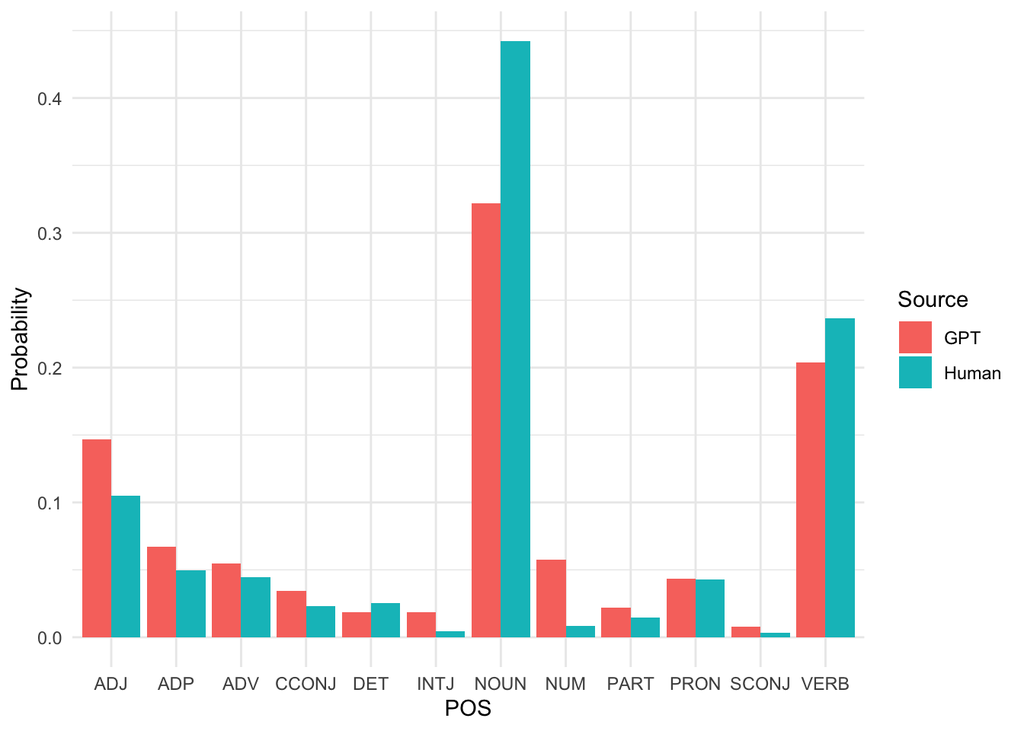

```r
mean_df <- bind_rows(
  Human = human_mean,
  GPT = gpt_mean,
  .id = "Source"
)

mean_df_long <- pivot_longer(
  mean_df,
  cols = -Source,
  names_to = "POS",
  values_to = "Probability"
)

ggplot(mean_df_long,
       aes(POS, Probability, fill = Source)) +
  geom_col(position = "dodge")
```

Этот график говорит, что с большой вероятностью и люди, и GPT выбирают такие категории как глагол, существительное и прилагательное. Еще по нему можно прикинуть, что эти распределения очень похожи и изменяются похоже.

# Анализ схожести распределений

## Метрика 1 - косинусное расстрояние

Для каждого контекста у нас рассчитаны вероятность выбора каждой POS. Таким образом, мы можем сравнивать контексты у людей и GPT между собой через вектора вероятностей.

```r
pos_cols <- names(human)

cosine_scores <- map_dbl(
  1:nrow(human),
  ~ cosine(
    as.numeric(human[.x, pos_cols]),
    as.numeric(gpt[.x, pos_cols])
  )
)

summary(cosine_scores)
```

```
##    Min. 1st Qu.  Median    Mean 3rd Qu.    Max.
##  0.0000  0.6183  0.9012  0.7652  0.9800  1.0000
```

По этим данным мы видим, что GPT в большинстве случаев очень близко воспроизводит данные людей (медианное сходство: 0.9012)

```r
pos_cols
```

```
##  [1] "ADJ"   "ADP"   "ADV"   "CCONJ" "DET"   "INTJ"  "NOUN"  "NUM"   "PART"
## [10] "PRON"  "SCONJ" "VERB"
```

## Метрика 2 - Дивергенция Йенсена — Шеннона

Дивергенция, чем она меньше, тем ближе два веткора.

```r
jsd_scores <- map_dbl(
  1:nrow(human),
  ~ JSD(
    rbind(
      as.numeric(human[.x, pos_cols]),
      as.numeric(gpt[.x, pos_cols])
    )
  )
)
```

```r
summary(jsd_scores)
```

```
##    Min. 1st Qu.  Median    Mean 3rd Qu.    Max.
##  0.0000  0.1045  0.1904  0.2508  0.3496  1.0000
```

# Распределение косинусной близости

## Косинусная близость

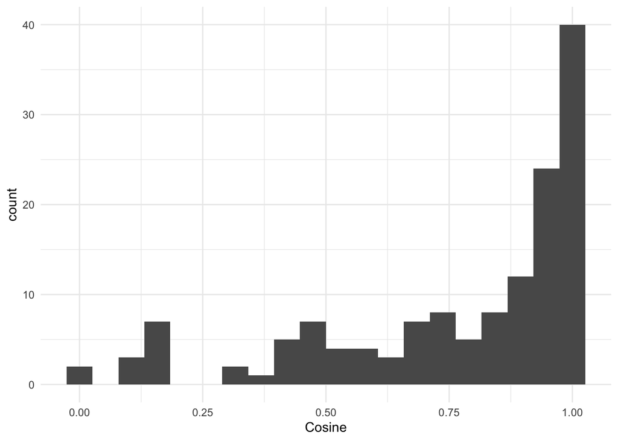

```r
ggplot(
  data.frame(Cosine = cosine_scores),
  aes(Cosine)
) +
  geom_histogram(bins = 20)
```

## Дивергенция Йенсена — Шеннона

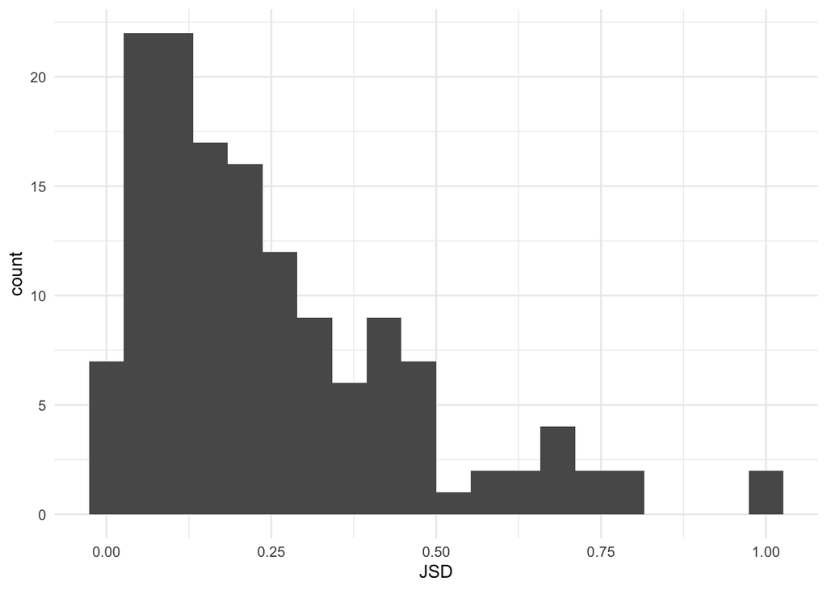

```r
ggplot(
  data.frame(JSD = jsd_scores),
  aes(JSD)
) +
  geom_histogram(bins = 20)
```

# Что на уровне контекстов?

```r
results <- tibble(
  context = rownames(human),
  cosine = cosine_scores,
  jsd = jsd_scores
)

head(results)
```

```
## # A tibble: 6 × 3
##   context                                        cosine    jsd
##   <chr>                                           <dbl>  <dbl>
## 1 А промывать манную                              0.922 0.141
## 2 Автор принадлежит к числу последних свидетелей  0.867 0.141
## 3 В багажнике были лопата,                        0.998 0.0470
## 4 В бассейне                                      0     1
## 5 В вопросе послышался упрёк                      0.475 0.447
## 6 В деревнях по-прежнему                          0.994 0.0411
```

## Самые похожие контексты

```r
results %>%
  arrange(desc(cosine)) %>%
  head(10)
```

```
## # A tibble: 10 × 3
##    context                                             cosine       jsd
##    <chr>                                                <dbl>     <dbl>
##  1 В темноте Иван задел острый                          1     0
##  2 Она с досадой                                        1     0
##  3 Торговля продуктами питания является одной из самых  1     0
##  4 Что ты хочешь чтобы тебе                             1     0
##  5 Какие главные лекарства должны                       1.00  0.0000636
##  6 Покуда я нахожусь у власти, я буду предметом         0.999 0.00159
##  7 Думаю, большой                                       0.999 0.0330
##  8 В лесу ветром                                        0.998 0.0506
##  9 В багажнике были лопата,                             0.998 0.0470
## 10 От внимания наблюдателя не должна                    0.997 0.0342
```

## Самые непохожие контексты

```r
results %>%
  arrange(cosine) %>%
  head(10)
```

```
## # A tibble: 10 × 3
##    context                                             cosine   jsd
##    <chr>                                                <dbl> <dbl>
##  1 В бассейне                                           0     1
##  2 У Пашки                                              0     1
##  3 Клиенты воровали из ресторана                        0.105 0.795
##  4 И на берегу озера тогда появляются                   0.110 0.689
##  5 На запись голоса                                     0.129 0.775
##  6 Применение микросхемы                                0.132 0.624
##  7 Когда она в самолёте                                 0.138 0.675
##  8 Возможности этих перемен будут обсуждаться в Париже  0.145 0.703
##  9 Я слезал, щупал                                      0.146 0.713
## 10 Я сделала                                            0.148 0.669
```

## Анализ

Из этих таблиц очень хорошо заметно, что в выборку входили данные с очень разными контекстами. Высокие показатели метрик попадаются в контекстах, которые можно назвать сильно ограничивающими, низние показатели - в слабо ограничивающих контекстах, где очень сложно предугадать следующее слово.

P.S. Терминология выше: strongly constraining contexts vs weakly constraining contexts

# Корреляция на уровне отдельных частей речи

Посмотрим, как корреляции выглядят для отдельных частей речи у людей и GPT.

```r
correlations <- map_dfr(
  pos_cols,
  function(pos){

    tibble(
      POS = pos,
      Correlation =
        cor(
          human[[pos]],
          gpt[[pos]],
          method = "spearman"
        )
    )

  }
)

correlations
```

```
## # A tibble: 12 × 2
##    POS   Correlation
##    <chr>       <dbl>
##  1 ADJ        0.455
##  2 ADP        0.309
##  3 ADV        0.384
##  4 CCONJ      0.355
##  5 DET        0.353
##  6 INTJ       0.0987
##  7 NOUN       0.773
##  8 NUM        0.579
##  9 PART       0.350
## 10 PRON       0.450
## 11 SCONJ      0.484
## 12 VERB       0.663
```

## Визуализируем корреляции

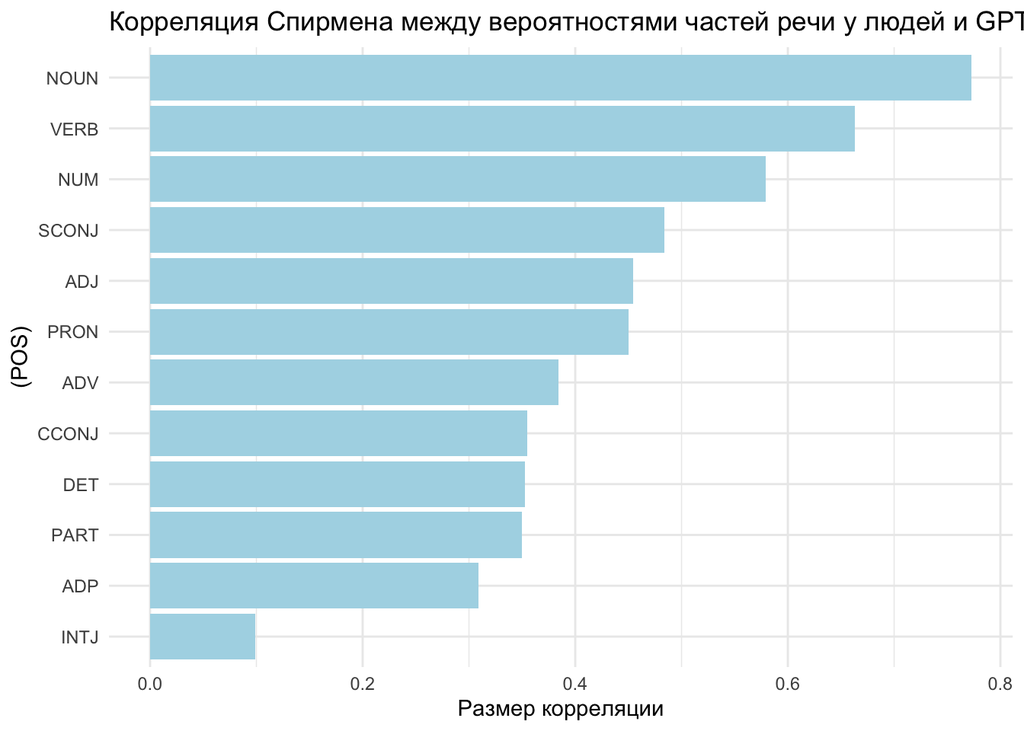

```r
ggplot(correlations,
       aes(reorder(POS, Correlation),
           Correlation)) +
  geom_col(fill = "lightblue") +
  coord_flip() +
  labs(
    title = "Корреляция Спирмена между вероятностями частей речи у людей и GPT",
    x = "(POS)",
    y = "Размер корреляции"
  ) +
  theme_minimal()
```

# Матрица корреляции

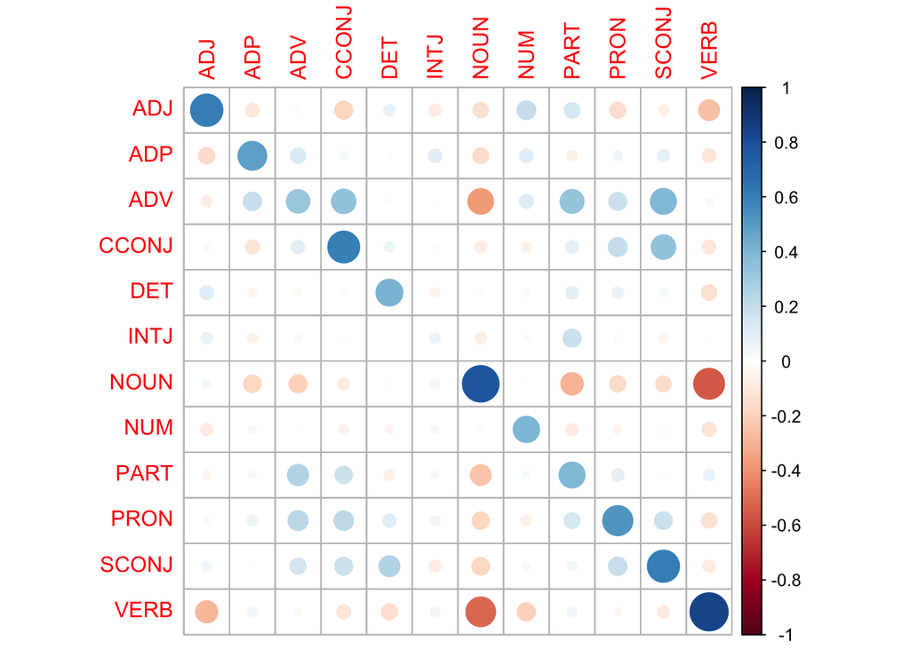

```r
human_mat <- as.matrix(human[pos_cols])
gpt_mat <- as.matrix(gpt[pos_cols])

cor_mat <- cor(human_mat, gpt_mat)

corrplot(cor_mat)
```

В этом corrplot интересно смотреть на размер корреляции по диагонали. Но в на этом графике есть интересная деталь. Можно заметить, что между существительными и глаголами сильная обратная корреляция. То есть когда предсказывается существительное, не предсказывается глагол и наоборот.

## Отношения между косинусной близостью и дивергенцией

```r
cor.test(
  cosine_scores,
  jsd_scores,
  method = "spearman"
)
```

```
##
##  Spearman's rank correlation rho
##
## data:  cosine_scores and jsd_scores
## S = 919910, p-value < 2.2e-16
## alternative hypothesis: true rho is not equal to 0
## sample estimates:
##        rho
## -0.9277608
```

При rho = -0.93 и p-value << 0.05 делаем вывод о том, что между двумя метриками есть сильная обратная связь. То есть, дивергенция падает, когда косинусная близость поднимается, что логично Это тест для самопроверки, что две метрики хорошо объясняют данные.

# Результаты

```r
summary_table <- tibble(
  Mean_Cosine = mean(cosine_scores),
  SD_Cosine = sd(cosine_scores),
  Mean_JSD = mean(jsd_scores),
  SD_JSD = sd(jsd_scores)
)

summary_table
```

```
## # A tibble: 1 × 4
##   Mean_Cosine SD_Cosine Mean_JSD SD_JSD
##         <dbl>     <dbl>    <dbl>  <dbl>
## 1       0.765     0.271    0.251  0.208
```

# Заключение

В этом исследовании получилось установить, что модели предсказывают следующее слово похожим на людей образом.

Про это говорят метрики косинусной близости: среднее значение 0.76 и дивергенции Йенсена - Шеннона: средняя дивергенция 0.25.

То есть при общей высокой схожести распределений в контекстах, метрика дивергенции показывает, что данные неоднородны и близость сильно связана с контекстом. В некоторых предсказания схожи, а в некоторых вся предсказания очень низкие, что объясняется “строгостью” контекста.